# Practical ML - Data Science specialization

Alessandro Pietrelli

2018-02-19

# Load libraries

```r
install_load <- function (package1, ...)  {

  # convert arguments to vector
  packages <- c(package1, ...)

  # start loop to determine if each package is installed
  for(package in packages){

    # if package is installed locally, load
    if(package %in% rownames(installed.packages()))
      do.call('library', list(package))

    #else use install.packages then load
    else {
      install.packages(package, repos = "http://cran.stat.unipd.it/")
      do.call("library", list(package))
    }

  }
}
libs = c("caret", "dplyr", "VIM")
install_load(libs)
```

[output not shown]

# Get the data

```r
data_dir = "./data"
training_url = "https://d396qusza40orc.cloudfront.net/predmachlearn/pml-training.csv"
test_url = "https://d396qusza40orc.cloudfront.net/predmachlearn/pml-testing.csv"
training_file = "pml-training.csv"
test_file = "pml-test.csv"
if (!file.exists(data_dir)) {
  dir.create(data_dir)
}
if (!file.exists(file.path(data_dir, training_file))) {
  download.file(training_url, destfile=file.path(data_dir, training_file))
}
if (!file.exists(file.path(data_dir, test_file))) {
  download.file(test_url, destfile=file.path(data_dir, test_file))
}
```

## Read the Data

Load the data into 2 different data frames

```r
train <- read.csv(file.path(data_dir, training_file))
test <- read.csv(file.path(data_dir, test_file))
dim(train)
```

```
[1] 19622   160
```

```r
dim(test)
```

```
[1]  20 160
```

```r
head(train)
```

|  | X | user_name | raw_timestamp_part_1 | raw_timestamp_part_2 | cvtd_timestamp | new_window | num_window | roll_belt | pitch_belt | yaw_belt | total_accel_belt | kurtosis_roll_belt | kurtosis_picth_belt | kurtosis_yaw_belt | skewness_roll_belt | skewness_roll_belt.1 | skewness_yaw_belt | max_roll_belt | max_picth_belt | max_yaw_belt | min_roll_belt | min_pitch_belt | min_yaw_belt | amplitude_roll_belt | amplitude_pitch_belt | amplitude_yaw_belt | var_total_accel_belt | avg_roll_belt | stddev_roll_belt | … |
| --- | --- | --- | --- | --- | --- | --- | --- | --- | --- | --- | --- | --- | --- | --- | --- | --- | --- | --- | --- | --- | --- | --- | --- | --- | --- | --- | --- | --- | --- | --- |
| 1 | 1 | carlitos | 1323084231 | 788290 | 05/12/2011 11:23 | no | 11 | 1.41 | 8.07 | -94.4 | 3 |  |  |  |  |  |  | NA | NA |  | NA | NA |  | NA | NA |  | NA | NA | NA | … |
| 2 | 2 | carlitos | 1323084231 | 808298 | 05/12/2011 11:23 | no | 11 | 1.41 | 8.07 | -94.4 | 3 |  |  |  |  |  |  | NA | NA |  | NA | NA |  | NA | NA |  | NA | NA | NA | … |
| 3 | 3 | carlitos | 1323084231 | 820366 | 05/12/2011 11:23 | no | 11 | 1.42 | 8.07 | -94.4 | 3 |  |  |  |  |  |  | NA | NA |  | NA | NA |  | NA | NA |  | NA | NA | NA | … |
| 4 | 4 | carlitos | 1323084232 | 120339 | 05/12/2011 11:23 | no | 12 | 1.48 | 8.05 | -94.4 | 3 |  |  |  |  |  |  | NA | NA |  | NA | NA |  | NA | NA |  | NA | NA | NA | … |
| 5 | 5 | carlitos | 1323084232 | 196328 | 05/12/2011 11:23 | no | 12 | 1.48 | 8.07 | -94.4 | 3 |  |  |  |  |  |  | NA | NA |  | NA | NA |  | NA | NA |  | NA | NA | NA | … |
| 6 | 6 | carlitos | 1323084232 | 304277 | 05/12/2011 11:23 | no | 12 | 1.45 | 8.06 | -94.4 | 3 |  |  |  |  |  |  | NA | NA |  | NA | NA |  | NA | NA |  | NA | NA | NA | … |

## Clean the data

Check if in the observations are present NA values or missing OBS that can raise errors/bias during the model training.

```r
sum(complete.cases(train))
```

```
[1] 406
```

Too few observation to have a correct training.

### Eliminate the columns with NA/missing values

Let’s see colnames

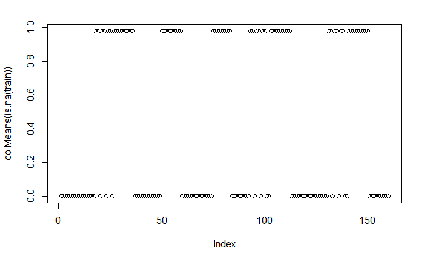

There are columns with a lot of missing values.

We will reatain only the columns without NA values

```r
trainRaw = train[, sapply(train, is.numeric)]
testRaw = test[, sapply(test, is.numeric)]
```

Remove columns with NA values

```r
trainFilter <- trainRaw[, colSums(is.na(trainRaw)) == 0]
testFilter <- testRaw[, colSums(is.na(testRaw)) == 0]
```

Dimension

```r
dim(trainFilter)
```

```
[1] 19622    54
```

```r
dim(testFilter)
```

```
[1] 20 54
```

[output not shown]

[output cut: 990 more lines]

Get dimension of the filtered dataset

```r
dim(trainFilter)
```

```
[1] 19622    53
```

```r
dim(testFilter)
```

```
[1] 20 54
```

## Slice the data

```r
set.seed(12022018) # Today's date
inTrain <- createDataPartition(trainFilter$classe, p=0.70, list=F)
trainData <- trainFilter[inTrain, ]
validationData <- trainFilter[-inTrain, ]
dim(trainData)
```

[output not shown]

# Data modeling

We will fit a model using **Random Forest** and **XGBoost** (very popular in challange like kaggle.com) for several reasons:

1. With tree-based models, **you can safely ignore** predictors correlation issues
2. Zero- and Near Zero-Variance Predictors **does not** imply on tree-based models
3. As each feature is processed separately, and the possible splits of the data don’t depend on scaling, no preprocessing like normalization or standardization of features is needed for decision tree algorithms.

## Random forest

### Model

```r
controlRf <- trainControl(method="cv", 5)
modelRf <- train(classe ~ ., data=trainData, method="rf", trControl=controlRf, ntree=250)
modelRf
```

```
Random Forest

13737 samples
   53 predictor
    5 classes: 'A', 'B', 'C', 'D', 'E'

No pre-processing
Resampling: Cross-Validated (5 fold)
Summary of sample sizes: 10989, 10990, 10990, 10989, 10990
Resampling results across tuning parameters:

  mtry  Accuracy   Kappa
   2    0.9919923  0.9898700
  27    0.9959963  0.9949355
  53    0.9927936  0.9908839

Accuracy was used to select the optimal model using the largest value.
The final value used for the model was mtry = 27.
```

### Performance of the model on the validation data set

```r
confusionMatrix(validationData$classe, predict_rf)
```

```
Confusion Matrix and Statistics

          Reference
Prediction    A    B    C    D    E
         A 1673    0    0    0    1
         B    2 1129    8    0    0
         C    0    2 1024    0    0
         D    0    0    2  962    0
         E    0    0    0    0 1082

Overall Statistics

               Accuracy : 0.9975
                 95% CI : (0.9958, 0.9986)
    No Information Rate : 0.2846
    P-Value [Acc > NIR] : < 2.2e-16

                  Kappa : 0.9968
 Mcnemar's Test P-Value : NA

Statistics by Class:

                     Class: A Class: B Class: C Class: D Class: E
Sensitivity            0.9988   0.9982   0.9903   1.0000   0.9991
Specificity            0.9998   0.9979   0.9996   0.9996   1.0000
Pos Pred Value         0.9994   0.9912   0.9981   0.9979   1.0000
Neg Pred Value         0.9995   0.9996   0.9979   1.0000   0.9998
Prevalence             0.2846   0.1922   0.1757   0.1635   0.1840
Detection Rate         0.2843   0.1918   0.1740   0.1635   0.1839
Detection Prevalence   0.2845   0.1935   0.1743   0.1638   0.1839
Balanced Accuracy      0.9993   0.9981   0.9950   0.9998   0.9995
```

Very accurate model to classify **classe** feature

## XGBoost

```r
modelXGB$modelInfo
```

```
$label
[1] "eXtreme Gradient Boosting"

$library
[1] "xgboost" "plyr"

$type
[1] "Regression"     "Classification"

$parameters
```

| parameter | class | label |
| --- | --- | --- |
| nrounds | numeric | # Boosting Iterations |
| max_depth | numeric | Max Tree Depth |
| eta | numeric | Shrinkage |
| gamma | numeric | Minimum Loss Reduction |
| colsample_bytree | numeric | Subsample Ratio of Columns |
| min_child_weight | numeric | Minimum Sum of Instance Weight |
| subsample | numeric | Subsample Percentage |

[output not shown]

[output cut: 167 more lines]

[output not shown]

```r
modelXGB
```

```
eXtreme Gradient Boosting

13737 samples
   53 predictor
    5 classes: 'A', 'B', 'C', 'D', 'E'

No pre-processing
Resampling: Cross-Validated (5 fold)
Summary of sample sizes: 10989, 10990, 10991, 10988, 10990
Resampling results across tuning parameters:

  eta  max_depth  colsample_bytree  subsample  nrounds  Accuracy   Kappa
  0.3  1          0.6               0.50        50      0.8130571  0.7630000
  0.3  1          0.6               0.50       100      0.8827974  0.8516047
  0.3  1          0.6               0.50       150      0.9169393  0.8948639
  0.3  1          0.6               0.75        50      0.8091988  0.7580610
  0.3  1          0.6               0.75       100      0.8823600  0.8510801
  0.3  1          0.6               0.75       150      0.9153361  0.8928512
  0.3  1          0.6               1.00        50      0.8118200  0.7613677
  0.3  1          0.6               1.00       100      0.8849089  0.8543212
  0.3  1          0.6               1.00       150      0.9160647  0.8937910
  0.3  1          0.8               0.50        50      0.8131297  0.7631086
  0.3  1          0.8               0.50       100      0.8853448  0.8548423
  0.3  1          0.8               0.50       150      0.9171566  0.8951287
  0.3  1          0.8               0.75        50      0.8127663  0.7625787
  0.3  1          0.8               0.75       100      0.8849078  0.8542995
  0.3  1          0.8               0.75       150      0.9173753  0.8954213
  0.3  1          0.8               1.00        50      0.8105822  0.7598251
  0.3  1          0.8               1.00       100      0.8846168  0.8539364
  0.3  1          0.8               1.00       150      0.9148997  0.8923266
  0.3  2          0.6               0.50        50      0.9520267  0.9393048
  0.3  2          0.6               0.50       100      0.9868237  0.9833326
  0.3  2          0.6               0.50       150      0.9956321  0.9944752
  0.3  2          0.6               0.75        50      0.9529015  0.9404256
  0.3  2          0.6               0.75       100      0.9864598  0.9828744
  0.3  2          0.6               0.75       150      0.9957781  0.9946598
  0.3  2          0.6               1.00        50      0.9535563  0.9412486
  0.3  2          0.6               1.00       100      0.9893720  0.9865557
  0.3  2          0.6               1.00       150      0.9965060  0.9955806
  0.3  2          0.8               0.50        50      0.9532645  0.9408745
```

[output cut: 72 more lines]

```
 0.4 3         0.8              0.50      100     0.9989081 0.9986190
 0.4 3         0.8              0.50      150     0.9989809 0.9987111
 0.4 3         0.8              0.75       50     0.9957054 0.9945679
 0.4 3         0.8              0.75      100     0.9989811 0.9987112
 0.4 3         0.8              0.75      150     0.9991994 0.9989873
 0.4 3         0.8              1.00       50     0.9948317 0.9934625
 0.4 3         0.8              1.00      100     0.9988355 0.9985271
 0.4 3         0.8              1.00      150     0.9991994 0.9989873

Tuning parameter 'gamma' was held constant at a value of 0
Tuning parameter 'min_child_weight' was held constant at a
 value of 1
Accuracy was used to select the optimal model using the largest value.
The final values used for the model were nrounds = 150, max_depth = 3, eta = 0.4, gamma = 0, colsample_bytree =
 0.6, min_child_weight = 1 and subsample = 0.75.
```

### Performance of the model on the validation data set

```r
predict_XGB <- predict(modelXGB, validationData)
confusionMatrix(validationData$classe, predict_XGB)
```

```
Confusion Matrix and Statistics

          Reference
Prediction    A    B    C    D    E
         A 1674    0    0    0    0
         B    2 1137    0    0    0
         C    0    0 1026    0    0
         D    0    0    0  964    0
         E    0    0    0    0 1082

Overall Statistics

               Accuracy : 0.9997
                 95% CI : (0.9988, 1)
    No Information Rate : 0.2848
    P-Value [Acc > NIR] : < 2.2e-16

                  Kappa : 0.9996
 Mcnemar's Test P-Value : NA

Statistics by Class:

                     Class: A Class: B Class: C Class: D Class: E
Sensitivity            0.9988   1.0000   1.0000   1.0000   1.0000
Specificity            1.0000   0.9996   1.0000   1.0000   1.0000
Pos Pred Value         1.0000   0.9982   1.0000   1.0000   1.0000
Neg Pred Value         0.9995   1.0000   1.0000   1.0000   1.0000
Prevalence             0.2848   0.1932   0.1743   0.1638   0.1839
Detection Rate         0.2845   0.1932   0.1743   0.1638   0.1839
Detection Prevalence   0.2845   0.1935   0.1743   0.1638   0.1839
Balanced Accuracy      0.9994   0.9998   1.0000   1.0000   1.0000
```

With XGB we reach a better accuracy on validation data.

Only 2 mislabeled prediction A->B

# Compare models

```r
# collect resamples
results <- resamples(list(RF=modelRf, XGB=modelXGB))
# summarize the distributions
summary(results)
```

```
Call:
summary.resamples(object = results)

Models: RF, XGB
Number of resamples: 5

Accuracy
         Min.   1st Qu.    Median      Mean   3rd Qu.      Max. NA's
RF  0.9930859 0.9959956 0.9959956 0.9959963 0.9970877 0.9978166    0
XGB 0.9985449 0.9989079 0.9996358 0.9992721 0.9996360 0.9996361    0

Kappa
         Min.   1st Qu.    Median      Mean   3rd Qu.      Max. NA's
RF  0.9912541 0.9949340 0.9949349 0.9949355 0.9963162 0.9972383    0
XGB 0.9981596 0.9986187 0.9995394 0.9990794 0.9995396 0.9995397    0
```

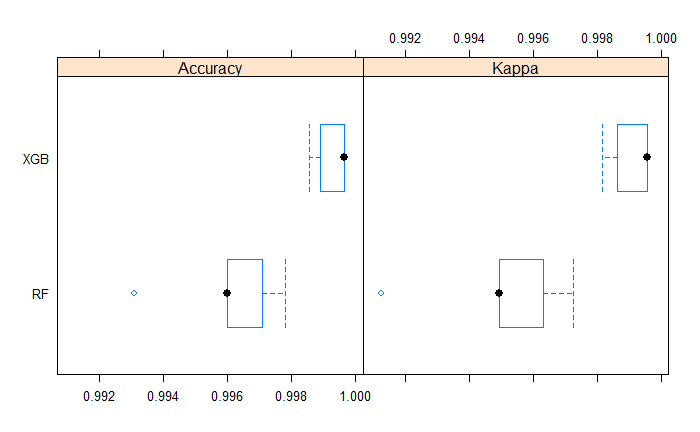

```r
# boxplots of results
bwplot(results)
```

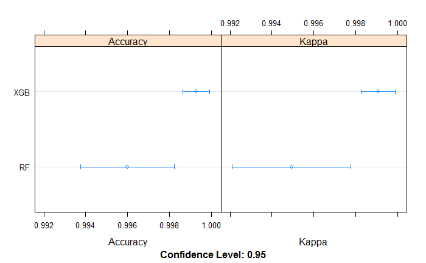

```r
# dot plots of results
dotplot(results)
```

# Predict Test data with RF and XGB

```r
resultRf <- predict(modelRf, testFilter[, -length(names(testFilter))])
resultXGB <- predict(modelXGB, testFilter[, -length(names(testFilter))])
resultRf
```

```
 [1] B A B A A E D B A A B C B A E E A B B B
Levels: A B C D E
```

```r
resultXGB
```

```
 [1] B A B A A E D B A A B C B A E E A B B B
Levels: A B C D E
```

```r
confusionMatrix(resultRf, resultXGB)
```

```
Confusion Matrix and Statistics

          Reference
Prediction A B C D E
         A 7 0 0 0 0
         B 0 8 0 0 0
         C 0 0 1 0 0
         D 0 0 0 1 0
         E 0 0 0 0 3

Overall Statistics

               Accuracy : 1
                 95% CI : (0.8316, 1)
    No Information Rate : 0.4
    P-Value [Acc > NIR] : 1.1e-08

                  Kappa : 1
 Mcnemar's Test P-Value : NA

Statistics by Class:

                     Class: A Class: B Class: C Class: D Class: E
Sensitivity              1.00      1.0     1.00     1.00     1.00
Specificity              1.00      1.0     1.00     1.00     1.00
Pos Pred Value           1.00      1.0     1.00     1.00     1.00
Neg Pred Value           1.00      1.0     1.00     1.00     1.00
Prevalence               0.35      0.4     0.05     0.05     0.15
Detection Rate           0.35      0.4     0.05     0.05     0.15
Detection Prevalence     0.35      0.4     0.05     0.05     0.15
Balanced Accuracy        1.00      1.0     1.00     1.00     1.00
```

Finally the model predict the TEST data in the same way, but we noticed that XGB works better with the trainig set